# scMultiSim Examples

First, load the package locally:

```r
(function() {
  installed <- installed.packages()[,"Package"]
  install <- function(list, fn) {
    pkg <- setdiff(list, installed)
    if (length(pkg)) fn(pkg)
  }

  r_packages <- c(
    "devtools", "dplyr", "ggplot2", "Rtsne",
    "reshape", "ape", "phytools", "repr", "KernelKnn",
    "gridExtra", "parallel", 'foreach', 'phytools', "doParallel",
    "zeallot", "gtools", "gplots", "stringi", "roxygen2"
  )
  install(r_packages, install.packages)

  if (!require("BiocManager", quietly = TRUE)) {
    install.packages("BiocManager")
    BiocManager::install(version = "3.15")
  }
  bioc_packages <- c('Biobase','IRanges','S4Vectors','SummarizedExperiment')
  install(bioc_packages, BiocManager::install)
})()
```

```r
library("devtools")
devtools::load_all(".")
```

```
ℹ Loading scMultiSim
```

```r
# library(gridExtra)
library("scMultiSim")
```

## Simulating True Counts

Simulate true counts by calling `sim_true_counts(options)` where `options` is a list. Use `scmultisim_help()` to get help.

```r
scmultisim_help("options")
```

```
scMultiSim  v1.0.0

[GENERAL]

rand.seed  (default: 0)
    Should produce same result if all other parameters are all the same.
    The value should be a numeric.
threads  (default: 1)
    Set to larger than 1 to use multithreading for some part of the simulati
    on.
    The value should be an integer between 1 and 4096.

[GENE]

GRN  (default: NULL)
    The GRN network.
    It should be a data frame with 3 columns (target, regulator, effect). Su
    pply NA to disable the GRN effect.
num.genes  (default: NULL)
    Number of genes if GRN is disabled.
    The value should be an integer between 1 and Inf.
unregulated.gene.ratio  (default: 0.1)
    Ratio of unreulated to regulated genes. Extra unregulated genes will be
    simulated in addition to the genes in GRN.
    The value should be a numeric between 0 and 1.
giv.mean  (default: 0)
    Mean of the Gene Identity Vectors.
    The value should be a numeric between 0 and Inf.
giv.prob  (default: 0.3)
    Probability of non-zero values in the Gene Identity Vectors.
    The value should be a numeric between 0 and 1.
giv.sd  (default: 1)
    Stddev of the Gene Identity Vectors.
    The value should be a numeric between 0 and Inf.
hge.range  (default: 1)
    Only choose highly expressed genes after this range.
    The value should be a numeric between 1 and Inf.
hge.prop  (default: 0)
    Propotion of highly expressed genes.
    The value should be a numeric between 0 and 1.
```

[output cut: 97 more lines]

```
num.cycles  (default: 3)
    For velocity mode, the number of cycles run before sampling the gene exp
    ression of a cell.
    The value should be an integer between 1 and Inf.
cycle.len  (default: 1)
    For velocity mode, a factor multiplied by the expected time to transitio
    n from kon to koff and back to to form the the length of a cycle.
    The value should be a numeric between 0 and Inf.

[SIMULATION - SPATIAL]

cci  (default: NA)
    The regulation network for spatial cell-cell interaction.
    Enables cell-cell interaction. See scmultisim_help("cci") for details.
NULL
```

scMultiSim provides two sample GRNs, `GRN_params_100` and `GRN_params_1139`. Load them first.

```r
data(GRN_params_100)
GRN_params <- GRN_params_100
GRN_params
```

| regulated.gene | regulator.gene | regulator.effect |
| --- | --- | --- |
| 16 | 10 | 1.768699 |
| 29 | 10 | 1.675360 |
| 62 | 10 | 3.723509 |
| 55 | 10 | 2.866182 |
| 81 | 80 | 4.020744 |
| 73 | 80 | 2.353371 |
| 73 | 6 | 3.003003 |
| 87 | 80 | 3.918432 |
| 95 | 80 | 1.956484 |
| 47 | 19 | 4.239982 |

[output cut: 120 more lines]

scMultiSim also provides three differentiation trees. `Phyla5()` and `Phyla3()` return bifurcating trees with 5 and 3 leaves respectively. `Phyla1()` returns only a single branch, which can be useful when we don’t want any trajectory.

```
Phylogenetic tree with 5 tips and 4 internal nodes.

Tip labels:
  1, 2, 3, 4, 5

Rooted; includes branch lengths.
```

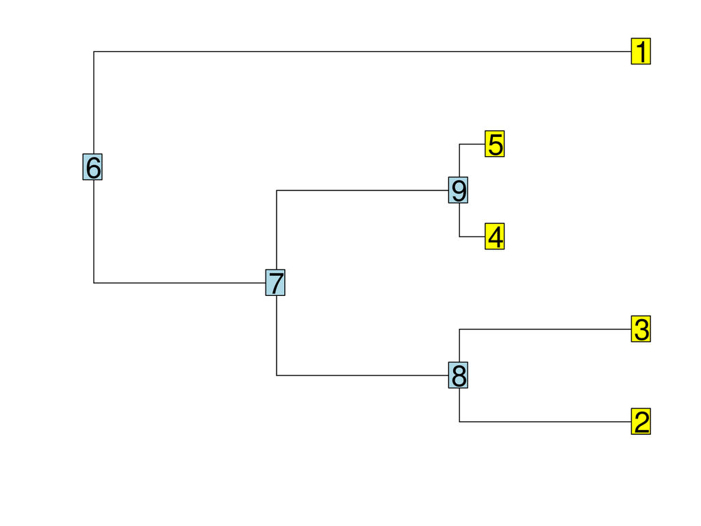

```r
Phyla5(plotting = T)
```

```
Phylogenetic tree with 3 tips and 2 internal nodes.

Tip labels:
  1, 2, 3

Rooted; includes branch lengths.
```

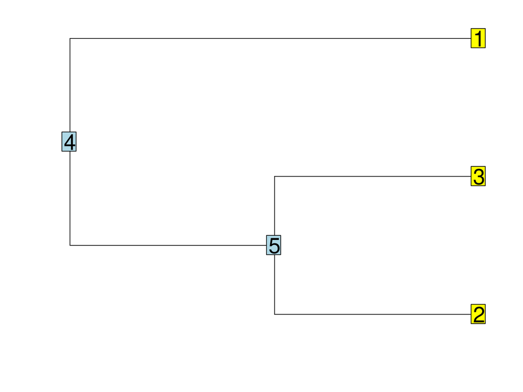

```r
Phyla3(plotting = T)
```

```r
# It's not possible to plot Phyla1() because it only contains 1 branch connecting two nodes.
Phyla1()
```

```
Phylogenetic tree with 1 tips and 1 internal nodes.

Tip labels:
  A

Rooted; includes branch lengths.
```

Now, we create the options list. The undocumented option `debug` will print out some useful information and return the internal simulation session in the result.

```r
options_ = list(
  rand.seed = 0,
  GRN = GRN_params,
  num.cells = 1000,
  num.cifs = 500,
  tree = Phyla5(),
  diff.cif.fraction = 0.8,
  do.velocity = T,
  intrinsic.noise = 1
  # debug = T
)
```

Run the simulation and check what kind of data is in the returned result:

```r
results <- sim_true_counts(options_)
```

```
Time spent: 0.35 mins
```

```r
names(results)
```

```
 [1] ".grn"             "unspliced_counts" ".options"         ".n"
 [5] "region_to_gene"   "atacseq_data"     "giv"              "kinetic_params"
 [9] "num_genes"        "velocity"         "cif"              "hge_scale"
[13] "counts"           "cell_meta"        "grn_params"       "cell_time"
```

Visualize the true counts and ATAC-seq data using `plot_tsne()`:

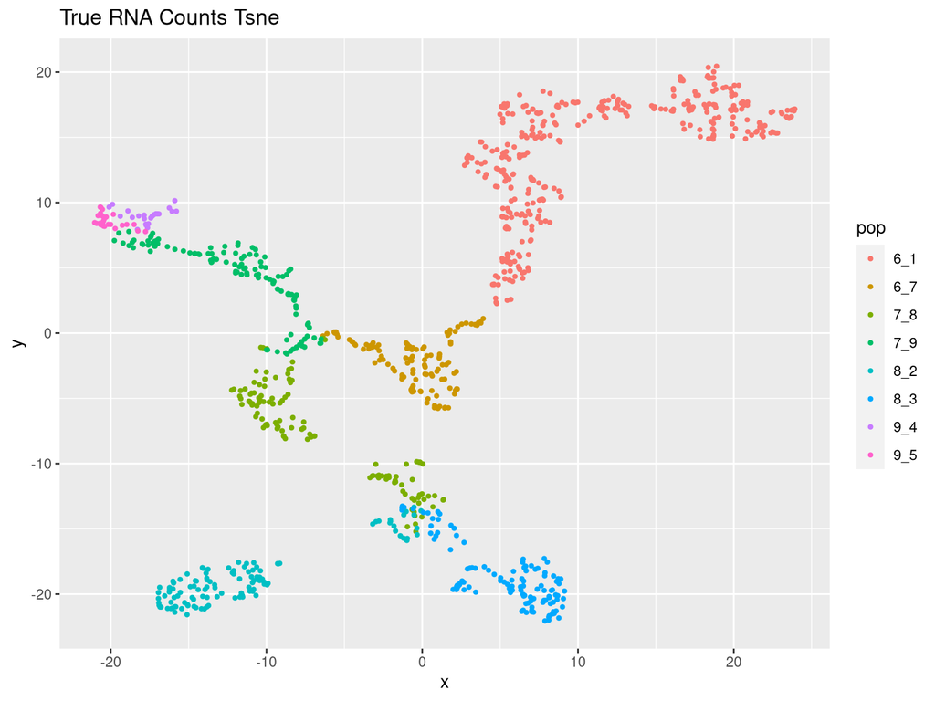

```r
plot_tsne(log2(results$counts + 1),
          results$cell_meta$pop,
          legend = 'pop', plot.name = 'True RNA Counts Tsne')
```

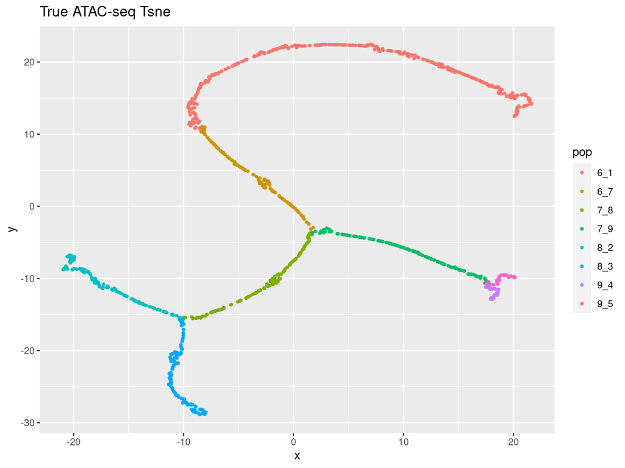

```r
plot_tsne(log2(results$atacseq_data + 1),
          results$cell_meta$pop,
          legend = 'pop', plot.name = 'True ATAC-seq Tsne')
```

We can also add the technical variation and batch effect to the true counts:

```r
# adds `counts_obs` to `results`
add_expr_noise(results)
```

```
Adding experimental noise...
50..100..150..200..250..300..350..400..450..500..550..600..650..700..750..800..850..900..950..1000..
```

```r
# adds `counts_with_batches` to `results`
divide_batches(results, nbatch = 2)
```

```
Adding batch effects...
```

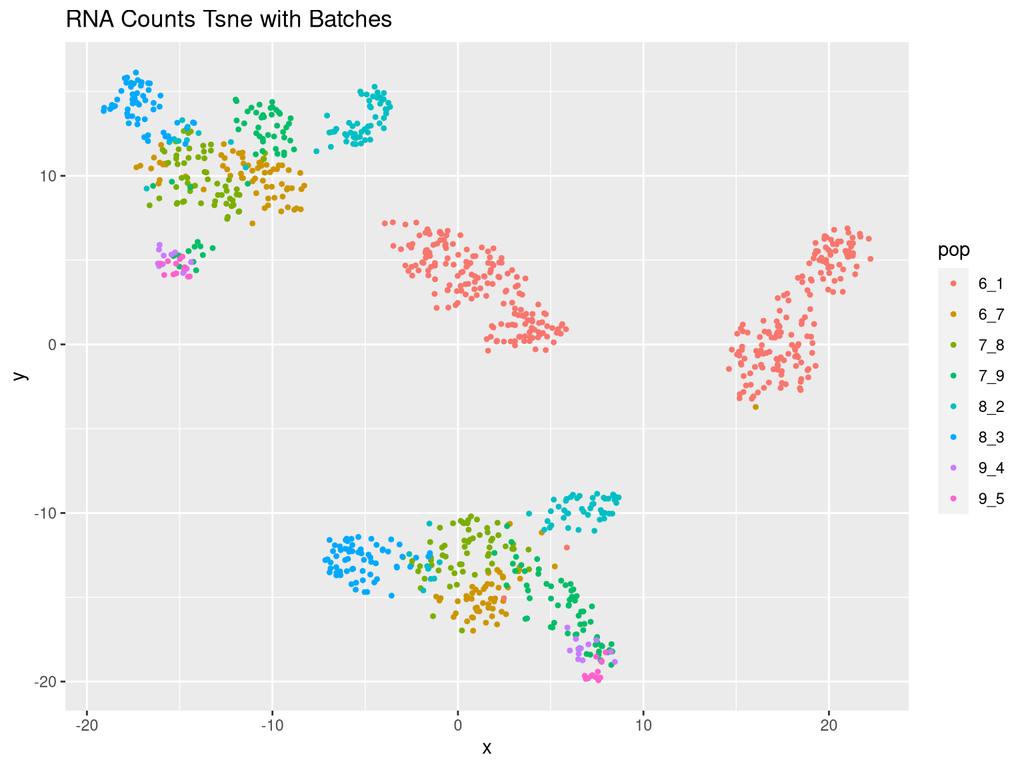

```r
plot_tsne(log2(results$counts_with_batches + 1),
          results$cell_meta$pop,
          legend = 'pop', plot.name = 'RNA Counts Tsne with Batches')
```

## Simulating dynamic GRN

First, call the following function to check the usage of dynamic GRN.

```r
scmultisim_help("dynamic.GRN")
```

```
Dynamic GRN deletes and creates some edges in the GRN in each epoch.
One epoch contains multiple steps, and the change is done gradually in steps.
The specific GRN at each step will be used by one or more cells sequentially.
When an epoch is done, another epoch will start.

Available options for dynamic.GRN:
  - seed: the random seed
  - num.steps: number of steps in each epoch.
  - cell.per.step: how many cells share the GRN in the same step.
  - involved.genes: a new edge will only be created within these specified genes.
      The default value is NA, which will use all existing genes in the GRN.
  - num.changing.edges: if < 1, it means the portion of edges added/deleted in each epoch.
      if >= 1, it means the number of edges added/deleted in each epoch.
  - create.tf.edges: whether a new edge can connect two TFs in the GRN.
  - weight.mean: the mean value of the weight for a newly created edge.
      The default value is NA, meaning that it will use the mean value of the input GRN.
  - weight.sd: the standard deviation of the weight for a newly created edge.

See the returned list for the default values.
NULL
```

Here we use `Phyla1()` as the differentiation tree to remove the effect of the trajectory. Additionally, we can use `discrete.cif = T` to simulate discrete cell population.

```r
options_ = list2(
  rand.seed = 0,
  GRN = GRN_params,
  num.cells = 1000,
  num.cifs = 500,
  tree = Phyla1(),
  diff.cif.fraction = 0.8,
  do.velocity = F,
  dynamic.GRN = list(
    cell.per.step = 3,
    num.changing.edges = 5,
    weight.mean = 0,
    weight.sd = 4
  ),
  intrinsic.noise = 0.5,
  # debug = T
)

results <- sim_true_counts(options_)
```

```
Time spent: 0.19 mins
```

`results$cell_specific_grn` is a list containing the gene effects matrix for each cell. Each row is a target and each column is a regulator. The corresponding gene names are displayed as column and row names.

```r
# GRN for cell 1 (first 10 rows)
results$cell_specific_grn[[1]][1:10,]
```

```
          2        6       10       19 80 91
1  2.250484 1.824607 1.941613 4.268812  0  0
2  0.000000 0.000000 0.000000 0.000000  0  0
3  2.184071 0.000000 0.000000 0.000000  0  0
4  1.634807 0.000000 0.000000 0.000000  0  0
5  4.677883 4.301893 2.090473 4.047174  0  0
6  0.000000 0.000000 0.000000 0.000000  0  0
7  3.306285 2.673968 2.414780 3.548154  0  0
8  2.707510 4.653263 1.357980 1.829304  0  0
9  1.501430 1.970649 4.359262 3.915318  0  0
10 0.000000 0.000000 0.000000 0.000000  0  0
```

Since we set `cell.per.step = 3`, we expect each adjacent 3 cells share the same GRN:

```r
print(all(results$cell_specific_grn[[1]] == results$cell_specific_grn[[2]]))
```

```
[1] TRUE
```

```r
print(all(results$cell_specific_grn[[2]] == results$cell_specific_grn[[3]]))
```

```
[1] TRUE
```

```r
print(all(results$cell_specific_grn[[3]] == results$cell_specific_grn[[4]]))
```

```
[1] FALSE
```

## Simulating Cell-cell interactions

Next, we use the `cci` option to enable cell-cell interactions. Check out the details of this option:

```r
scmultisim_help("cci")
```

```
To enable simulating cell-cell interaction, the value should be a list including
the following names:

- params: (data.frame)
    The spatial effect between neighbor cells.
    It should be a data frame similar to the GRN parameter.
- step.size: (number, optional)
    If using continuous population, use this step size to further divide the
    cell types on the tree. For example, if the tree only has one branch 1 -> 2
    and the branch length is 1 while the step size is 0.34, there will be totally
    three cell types: 1_2_1, 1_2_2, 1_2_3.
- cell.type.interaction: ("random" or a matrix)
    The interaction level between different cell types.
    They act as factors multiplied to the ligand effect.
    Supply the string "random" to let scMultiSim generate these factors randomly.
    Otherwise, use cci_cell_type_params() to generate the template data structure.
- max.neighbors: (integer from 1 to 4, optional)
    Constraint the maxinum number of neighbors with CCI for each cell.
    The neighbors with CCI will be randomly sampled.
      NULL
```

Simulating cell-cell interactions may take some time.

```r
options_ <- list2(
  rand.seed = 0,
  GRN = GRN_params_100,
  num.genes = 200,
  num.cells = 500,
  num.cifs = 50,
  tree = Phyla3(),
  intrinsic.noise = 0.5,
  cci = list(
    params = lig_params,
    max.neighbors = 4,
    cell.type.interaction = "random",
    step.size = 0.5
  )
)

results <- sim_true_counts(options_)
```

```
CCI simulation is enabled.
Get CIF...100..200..300..400..500..Done
Get params...Done
Simulating...50..100..150..200..250..300..350..400..450..500..
Time spent: 26.17 mins
```

We can use `plot_cell_loc` to view the spatial location of cells.

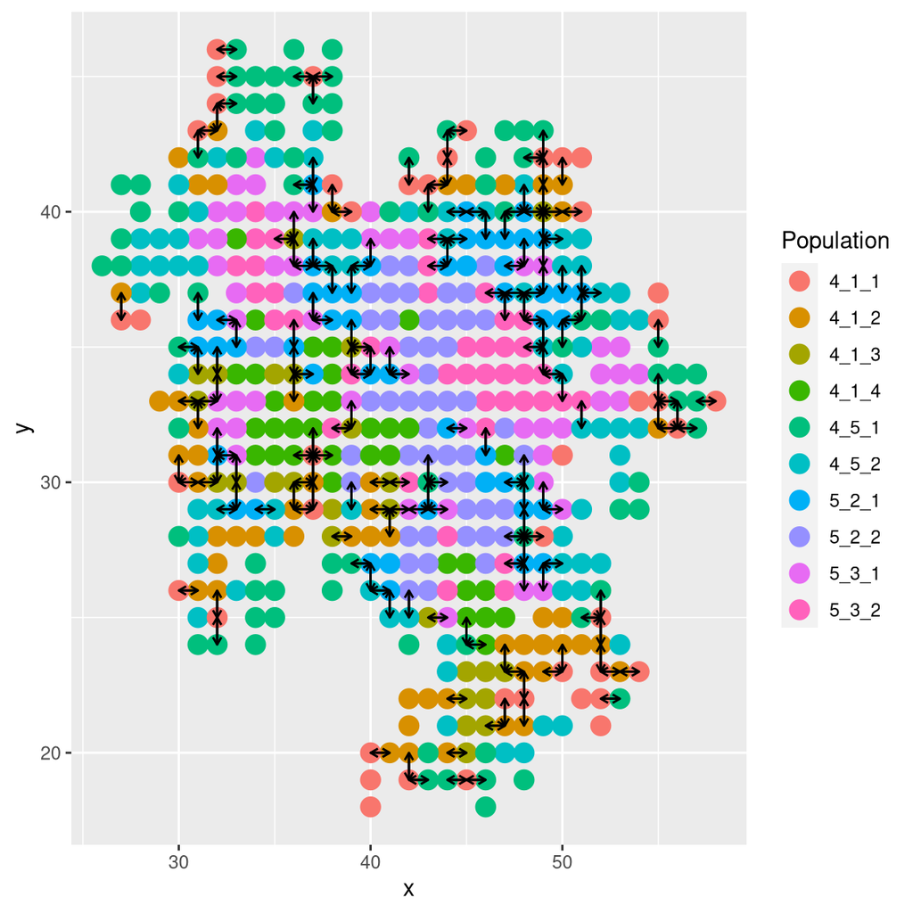

```r
plot_cell_loc(results)
```

Get the coordinates of each cell:

```r
results$cci_locs[1:5,]
```

```
       x  y
cell1 34 34
cell2 37 33
cell3 44 34
cell4 34 39
cell5 45 26
```

Get the cell types used in CCI. Since we specified `step.size = 0.5`, An intermediate cell type was added on each tree branch.

```r
results$cci_cell_types
```

```
4_5_1 4_5_2 5_2_1 5_2_2 5_3_1 5_3_2 4_1_1 4_1_2 4_1_3 4_1_4
    1     2     3     4     5     6     7     8     9    10
```

A new column `cell.type.idx` is available in cell metadata, indicating each cell’s cell type used when simulating cell-cell ineraction.

```r
results$cell_meta[1:5,]
```

|  | pop | depth | cell.type | cell.type.idx |
| --- | --- | --- | --- | --- |
| cell1 | 4_1 | 1.987928 | 4_1_4 | 10 |
| cell2 | 4_1 | 1.987928 | 4_1_4 | 10 |
| cell3 | 5_3 | 1.995968 | 5_3_2 | 6 |
| cell4 | 5_3 | 1.991935 | 5_3_2 | 6 |
| cell5 | 4_1 | 1.987928 | 4_1_4 | 10 |

Get the CCI ground truth between each cell type.

```r
results$cci_cell_type_param
```

| ligand | receptor | effect | ct1 | ct2 |
| --- | --- | --- | --- | --- |
| gene103 | gene101 | 5.2 | 1 | 3 |
| gene103 | gene101 | 5.2 | 1 | 4 |
| gene103 | gene101 | 5.2 | 1 | 7 |
| gene103 | gene101 | 5.2 | 1 | 10 |
| gene103 | gene101 | 5.2 | 2 | 3 |
| gene103 | gene101 | 5.2 | 2 | 4 |
| gene103 | gene101 | 5.2 | 2 | 6 |
| gene103 | gene101 | 5.2 | 3 | 1 |
| gene103 | gene101 | 5.2 | 3 | 2 |
| gene103 | gene101 | 5.2 | 3 | 5 |

[output cut: 56 more lines]